# 3. Nested Suicidality Discrete-Time Hazard (within lifetime BD cases)

## 1) Helper Functions

## 2) Fit DTH Models (primary + sensitivities) and Export

```
Fitting primary (logit): si_passive
```

```
  Subset stats -> n=726, ids=416, fam=412, site=21, events=145, nonevents=581
```

```
[si_passive | primary GLM logit] GLM refit; overdisp_K=0.996, max_VIF=1.08
```

```
Dropping near-zero RE: family_id.(Intercept), site_factor.(Intercept)
```

```
[si_passive | QC GLMM logit] converged=NA, singular=TRUE, overdisp_K=0.995, max_VIF=1.08; RE=(participant_id)
```

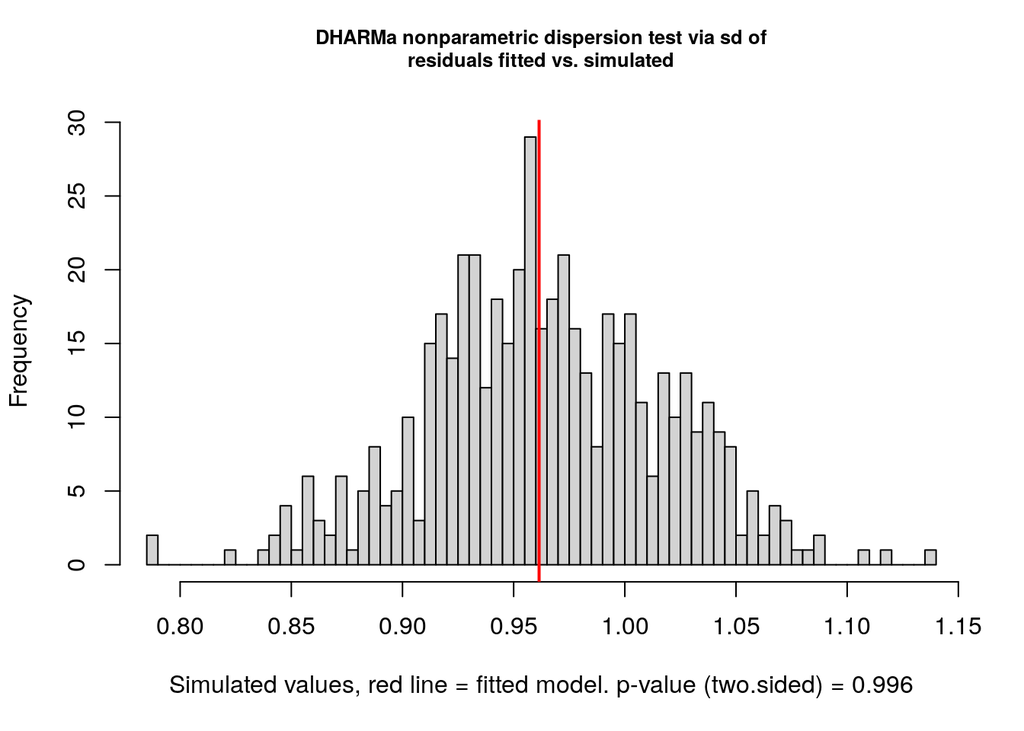

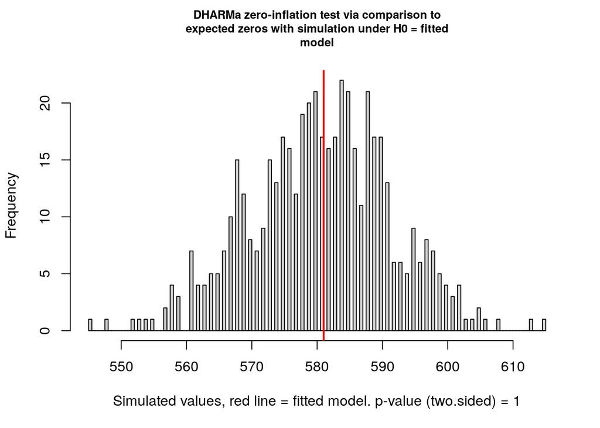

```
  Sensitivity (cloglog + offset log_dt): si_passive
```

```
  Subset stats -> n=726, ids=416, fam=412, site=21, events=145, nonevents=581
```

```
[si_passive | sens cloglog+offset] GLM refit; overdisp_K=0.996, max_VIF=1.06
```

```
  Sensitivity (bd_any_end): si_passive
```

```
  Subset stats -> n=726, ids=416, fam=412, site=21, events=145, nonevents=581
```

```
[si_passive | sens bd_any_end] GLM refit; overdisp_K=1.001, max_VIF=1.17
```

```
  Sensitivity (lag1 bd_any_start): si_passive
```

```
[si_passive | sens lag1(bd_any_start)] GLM refit; overdisp_K=0.996, max_VIF=1.08
```

```r
OUTCOMES <- SUIC_OUTCOMES

fits_primary <- list(); wald_primary <- list(); cr2_primary <- list()
preds_primary_age <- list(); hazards_wave_bd <- list()
bd_contrasts <- list()
cal_primary <- list(); auc_primary <- list(); diag_primary <- list(); perf_primary <- list()
dharma_tests_primary <- list()

fits_qc_glmm <- list()
diag_qc_glmm <- list()

fits_sens_cloglog <- list(); wald_sens_cloglog <- list(); cr2_sens_cloglog <- list()
fits_sens_end <- list(); wald_sens_end <- list()
fits_sens_lag1 <- list(); wald_sens_lag1 <- list()

# Build lag1 BD-start (per participant; robust to outcome)
su_pp_model <- su_pp_model %>%
  arrange(
    participant_id,
    if ("interval_index" %in% names(.)) interval_index else as.integer(end_wave)) %>%
  group_by(participant_id) %>%
  mutate(bd_any_start_lag1 = dplyr::lag(bd_any_start)) %>%
  ungroup()

for (out in OUTCOMES) {
  message("Fitting primary (", params$link_primary, "): ", out)
  dat_o <- su_pp_model %>%
    filter(outcome == out) %>%
    droplevels() %>%
    ensure_group_factors()

  # scale ages for SA only (z-score), and stash scales for prediction
  if (identical(out, "sa")) {
    sb <- c(mean(dat_o$age_mid_between, na.rm = TRUE),
            stats::sd(dat_o$age_mid_between, na.rm = TRUE))
    sc <- c(mean(dat_o$age_mid_cwc,     na.rm = TRUE),
            stats::sd(dat_o$age_mid_cwc,     na.rm = TRUE))
    dat_o <- dat_o %>%
      mutate(
        age_mid_between = (age_mid_between - sb[1]) / sb[2],
        age_mid_cwc     = (age_mid_cwc     - sc[1]) / sc[2])

    # store scales so the prediction helpers can invert back to raw ages
    attr(dat_o, "age_between_scale") <- sb
    attr(dat_o, "age_cwc_scale")     <- sc
  }

  # skip empty/degenerate subsets
  if (!can_fit_binomial(dat_o)) {
    message("  Skipping ", out, " (no rows or no 0/1 variation in event).")
    next
  }

  # Build/prune AFTER cleaning factors
  form_o <- build_formula(bd_var = "bd_any_start")
  form_o <- prune_formula_for_data(form_o, dat_o)

  # SA: avoid collinearity with post_baseline (two-wave design)
  if (identical(out, "sa")) {
    form_o <- update.formula(form_o, . ~ . - age_mid_cwc)
  }

  dbg <- dat_o %>% summarise(
    n = dplyr::n(),
    n_ids = dplyr::n_distinct(participant_id),
    n_fam = dplyr::n_distinct(family_id),
    n_site = dplyr::n_distinct(site_factor),
    events = sum(event == 1L, na.rm = TRUE),
    nonevents = sum(event == 0L, na.rm = TRUE))
  message(glue::glue("  Subset stats -> n={dbg$n}, ids={dbg$n_ids}, fam={dbg$n_fam}, site={dbg$n_site}, events={dbg$events}, nonevents={dbg$nonevents}"))

  # ----- PRIMARY: GLM (fixed effects) -----
  fit_o <- fit_glm_primary(form_o, dat_o, link = params$link_primary)
  fits_primary[[out]] <- fit_o
  msg_model_health(fit_o, glue("{out} | primary GLM {params$link_primary}"))

  # ----- OPTIONAL QC: GLMM (secondary; may fail / simplify) -----
  form_re <- build_formula(bd_var = "bd_any_start", include_re = TRUE)
  form_re <- prune_formula_for_data(form_re, dat_o)

  # keep SA collinearity guard consistent
  if (identical(out, "sa")) {
    form_re <- update.formula(form_re, . ~ . - age_mid_cwc)
  }

  fit_re <- safe_or_null(fit_glmer_secondary(form_re, dat_o, link = params$link_primary))
  if (!is.null(fit_re)) {
    fit_re <- refit_if_boundary(fit_re, form_re, dat_o, link = params$link_primary)
    fit_re <- simplify_random_effects(fit_re, form_re, dat_o, link = params$link_primary)
    msg_model_health(fit_re, glue("{out} | QC GLMM {params$link_primary}"))
  }

  fits_qc_glmm[[out]] <- fit_re
  diag_qc_glmm[[out]] <- if (!is.null(fit_re)) safe_or_null(diag_report(fit_re) %>% mutate(outcome = out, model = "QC_GLMM", .before = 1)) else NULL

  # Summaries
  wald_primary[[out]] <- safe_or_null(tidy_wald(fit_o) %>% mutate(outcome = out, model = params$link_primary, .before = 1))
  cr2_primary[[out]] <- safe_or_null({
    cl <- if ("participant_id" %in% names(dat_o) && nlevels(droplevels(dat_o$participant_id)) >= 2) {
      dat_o$participant_id
    } else if ("family_id" %in% names(dat_o) && nlevels(droplevels(dat_o$family_id)) >= 2) {
      dat_o$family_id
    } else {
      NULL
    }
    tidy_cr2(fit_o, cluster_var = cl) %>%
      mutate(outcome = out, model = params$link_primary, .before = 1)
  })

  cal_primary[[out]]  <- safe_or_null(calibration_df(fit_o, dat_o) %>% mutate(outcome = out, model = params$link_primary, .before = 1))
  auc_primary[[out]]  <- safe_or_null(tibble(outcome = out, model = params$link_primary, AUC = auc_interval(fit_o, dat_o)))
  diag_primary[[out]] <- safe_or_null(diag_report(fit_o) %>% mutate(outcome = out, model = params$link_primary, .before = 1))
  perf_primary[[out]] <- safe_or_null(perf_metrics(fit_o, dat_o) %>% mutate(outcome = out, model = params$link_primary, .before = 1))
  dharma_tests_primary[[out]] <- safe_or_null(save_dharma_plots_and_tests(fit_o, glue::glue("primary_{out}")))

  # Predictions & BD contrasts
  preds_primary_age[[out]] <- safe_or_null(
    pred_by_age_by_bd(fit_o, dat_o, bd_var = "bd_any_start", ages = ages_pred_vec, wave_ref = params$wave_ref) %>%
      mutate(outcome = out, model = params$link_primary, wave_ref = params$wave_ref, .before = 1))
  hazards_wave_bd[[out]] <- safe_or_null(
  hazard_by_period_by_bd(fit_o, dat_o, bd_var = "bd_any_start") %>%
    mutate(outcome = out, model = params$link_primary, .before = 1))
  bd_contrasts[[out]] <- safe_or_null(
    bd_contrasts_by_age(fit_o, dat_o, bd_var = "bd_any_start", ages = ages_pred_vec, wave_ref = params$wave_ref) %>%
      mutate(outcome = out, model = params$link_primary, .before = 1))

  # SENSITIVITY 1: cloglog + offset(log_dt)
  message("  Sensitivity (cloglog + offset log_dt): ", out)
  form_s1 <- update.formula(formula(fit_o), . ~ . + offset(log_dt))
  form_s1 <- prune_formula_for_data(form_s1, dat_o)
  dbg <- dat_o %>% summarise(
  n = dplyr::n(),
  n_ids = dplyr::n_distinct(participant_id),
  n_fam = dplyr::n_distinct(family_id),
  n_site = dplyr::n_distinct(site_factor),
  events = sum(event == 1L, na.rm = TRUE),
  nonevents = sum(event == 0L, na.rm = TRUE))
  message(glue::glue("  Subset stats -> n={dbg$n}, ids={dbg$n_ids}, fam={dbg$n_fam}, site={dbg$n_site}, events={dbg$events}, nonevents={dbg$nonevents}"))
  fit_s1 <- fit_glm_primary(form_s1, dat_o, link = "cloglog")
  msg_model_health(fit_s1, glue("{out} | sens cloglog+offset"))
  fits_sens_cloglog[[out]] <- fit_s1
  wald_sens_cloglog[[out]] <- safe_or_null(tidy_wald(fit_s1) %>% mutate(outcome = out, model = "cloglog", .before = 1))
  cr2_sens_cloglog[[out]]  <- safe_or_null(tidy_cr2(fit_s1, cluster_var = dat_o$family_id) %>%
                                         mutate(outcome = out, model = "cloglog", .before = 1))

  # SENSITIVITY 2: use bd_any_end instead of bd_any_start
  message("  Sensitivity (bd_any_end): ", out)
  if (all(!is.na(dat_o$bd_any_end))) {
    form_s2 <- build_formula(bd_var = "bd_any_end")
    form_s2 <- prune_formula_for_data(form_s2, dat_o)
    if (identical(out, "sa")) {
     form_s2 <- update.formula(form_s2, . ~ . - age_mid_cwc)
    }
    dbg <- dat_o %>% summarise(
    n = dplyr::n(),
    n_ids = dplyr::n_distinct(participant_id),
    n_fam = dplyr::n_distinct(family_id),
    n_site = dplyr::n_distinct(site_factor),
    events = sum(event == 1L, na.rm = TRUE),
    nonevents = sum(event == 0L, na.rm = TRUE))
    message(glue::glue("  Subset stats -> n={dbg$n}, ids={dbg$n_ids}, fam={dbg$n_fam}, site={dbg$n_site}, events={dbg$events}, nonevents={dbg$nonevents}"))
    fit_s2 <- fit_glm_primary(form_s2, dat_o, link = params$link_primary)
    msg_model_health(fit_s2, glue("{out} | sens bd_any_end"))
    fits_sens_end[[out]] <- fit_s2
    wald_sens_end[[out]] <- safe_or_null(tidy_wald(fit_s2) %>% mutate(outcome = out, model = "logit_bd_end", .before = 1))
  }

# SENSITIVITY 3: lag1(bd_any_start) to probe temporality
message("  Sensitivity (lag1 bd_any_start): ", out)
if (any(!is.na(dat_o$bd_any_start_lag1))) {
  dat_lag <- dat_o %>%
    filter(!is.na(bd_any_start_lag1)) %>%
    droplevels() %>%
    ensure_group_factors()
  if (can_fit_binomial(dat_lag) && has_two_levels(dat_lag$bd_any_start_lag1)) {
    form_s3 <- build_formula(bd_var = "bd_any_start_lag1")
    form_s3 <- prune_formula_for_data(form_s3, dat_lag)
    if (identical(out, "sa")) {
      form_s3 <- update.formula(form_s3, . ~ . - age_mid_cwc)
    }
    fit_s3 <- fit_glm_primary(form_s3, dat_lag, link = params$link_primary)
    msg_model_health(fit_s3, glue("{out} | sens lag1(bd_any_start)"))
    fits_sens_lag1[[out]] <- fit_s3
    wald_sens_lag1[[out]] <- safe_or_null(
      tidy_wald(fit_s3) %>% mutate(outcome = out, model = "logit_bd_lag1", .before = 1)
    )
  } else {
    message("  Skipping lag1 model for ", out, " (no variation / not fit-able).")
  }
} else {
  message("  Skipping lag1 model for ", out, " (all lagged BD missing).")
}

# ... just before closing the for(out in OUTCOMES) loop:
cat("\n\n### Final model for ", out, "\n")
print(formula(fit_o))
cat("\n\n")
if (inherits(fit_o, "merMod")) {
  print(lme4::VarCorr(fit_o))
} else {
  cat("No random-effects variance (GLM refit).\n")
}
cat("\n\n")
}
```

### Final model for si_passive

event ~ cluster + age_mid_between + sex + end_wave + bd_any_start <environment: 0x55a829a8cee0>

No random-effects variance (GLM refit).

```
Fitting primary (logit): si_active
```

```
  Subset stats -> n=787, ids=444, fam=440, site=21, events=154, nonevents=633
```

```
[si_active | primary GLM logit] GLM refit; overdisp_K=0.995, max_VIF=1.07
```

```
Dropping near-zero RE: family_id.(Intercept), site_factor.(Intercept)
```

```
[si_active | QC GLMM logit] converged=NA, singular=TRUE, overdisp_K=0.992, max_VIF=1.07; RE=(participant_id)
```

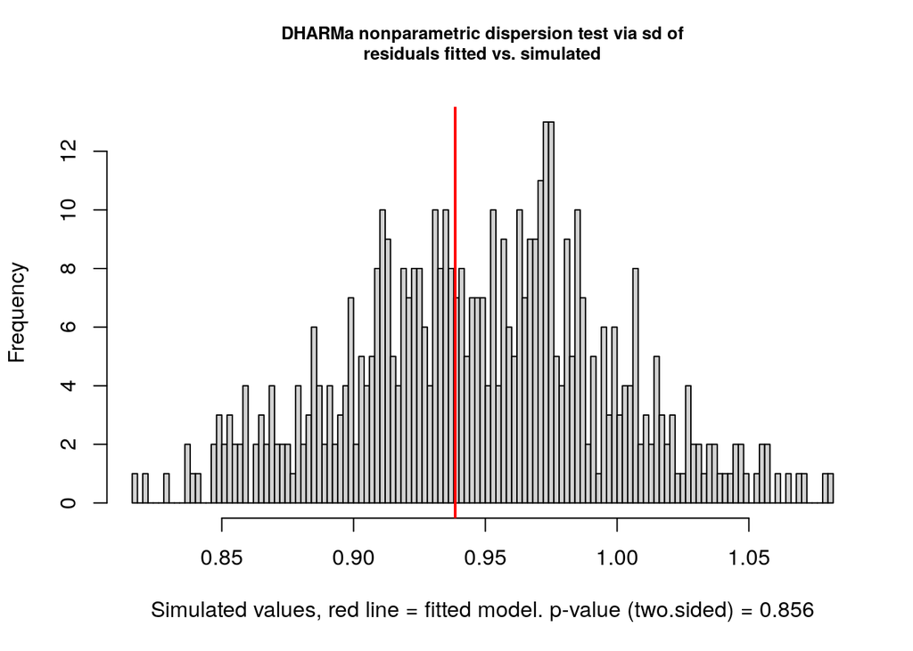

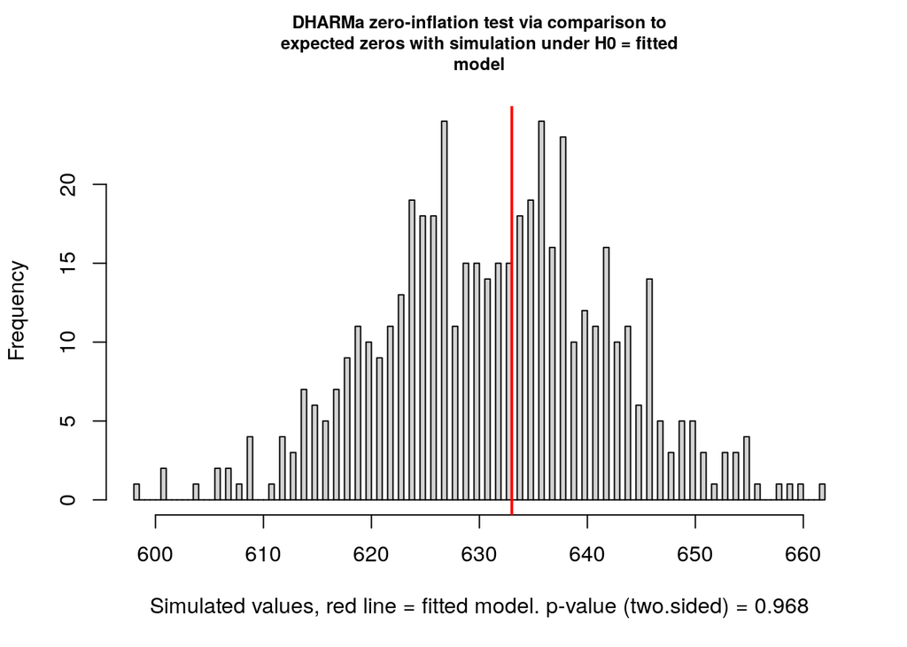

```
  Sensitivity (cloglog + offset log_dt): si_active
```

```
  Subset stats -> n=787, ids=444, fam=440, site=21, events=154, nonevents=633
```

```
[si_active | sens cloglog+offset] GLM refit; overdisp_K=1.006, max_VIF=1.06
```

```
  Sensitivity (bd_any_end): si_active
```

```
  Subset stats -> n=787, ids=444, fam=440, site=21, events=154, nonevents=633
```

```
[si_active | sens bd_any_end] GLM refit; overdisp_K=1.002, max_VIF=1.13
```

```
  Sensitivity (lag1 bd_any_start): si_active
```

```
[si_active | sens lag1(bd_any_start)] GLM refit; overdisp_K=0.995, max_VIF=1.08
```

### Final model for si_active

event ~ cluster + age_mid_between + sex + end_wave + bd_any_start <environment: 0x55a83254f630>

No random-effects variance (GLM refit).

```
Fitting primary (logit): sa
```

```
  Subset stats -> n=998, ids=542, fam=537, site=21, events=79, nonevents=919
```

```
[sa | primary GLM logit] GLM refit; overdisp_K=0.994, max_VIF=1.08
```

```
[sa | QC GLMM logit] converged=NA, singular=FALSE, overdisp_K=0.324, max_VIF=1.04; RE=(participant_id, family_id, site_factor)
```

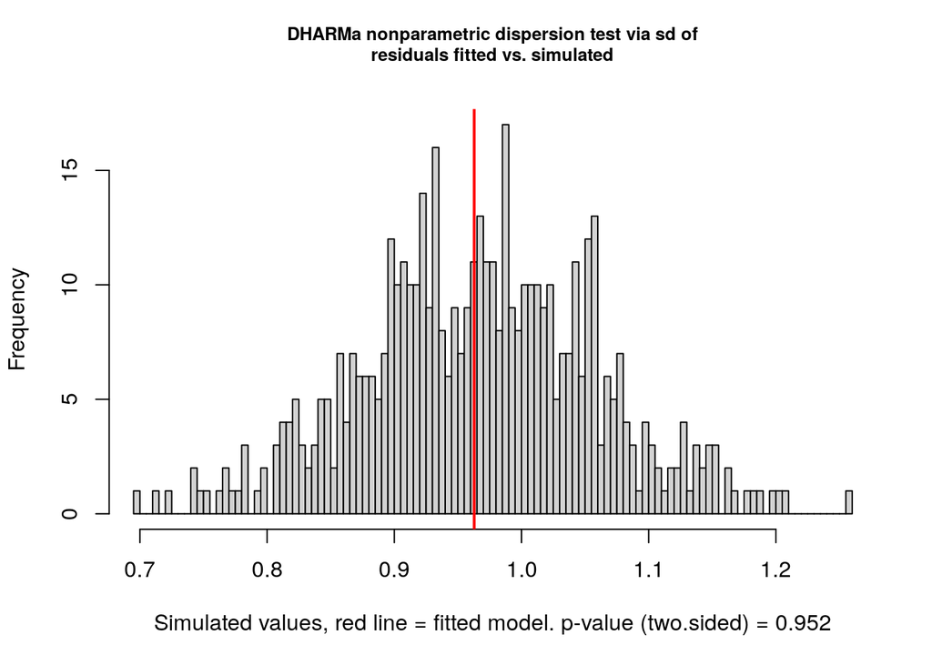

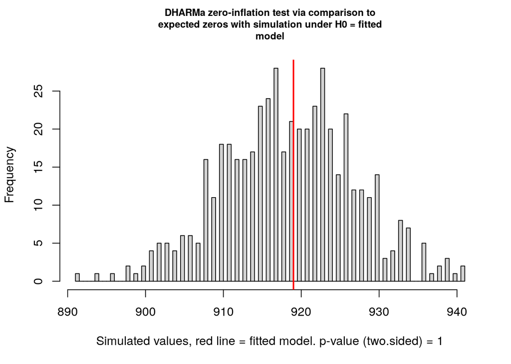

```
  Sensitivity (cloglog + offset log_dt): sa
```

```
  Subset stats -> n=998, ids=542, fam=537, site=21, events=79, nonevents=919
```

```
[sa | sens cloglog+offset] GLM refit; overdisp_K=0.999, max_VIF=1.08
```

```
  Sensitivity (bd_any_end): sa
```

```
  Subset stats -> n=998, ids=542, fam=537, site=21, events=79, nonevents=919
```

```
[sa | sens bd_any_end] GLM refit; overdisp_K=0.998, max_VIF=1.08
```

```
  Sensitivity (lag1 bd_any_start): sa
```

```
[sa | sens lag1(bd_any_start)] GLM refit; overdisp_K=1.004, max_VIF=1.09
```

### Final model for sa

event ~ cluster + age_mid_between + sex + end_wave + bd_any_start <environment: 0x55a82e22e398>

No random-effects variance (GLM refit).

```
Fitting primary (logit): nssi
```

```
  Subset stats -> n=803, ids=459, fam=455, site=21, events=160, nonevents=643
```

```
[nssi | primary GLM logit] GLM refit; overdisp_K=1.004, max_VIF=1.08
```

```
[nssi | QC GLMM logit] converged=NA, singular=TRUE, overdisp_K=0.998, max_VIF=1.26; RE=(participant_id, family_id, site_factor)
```

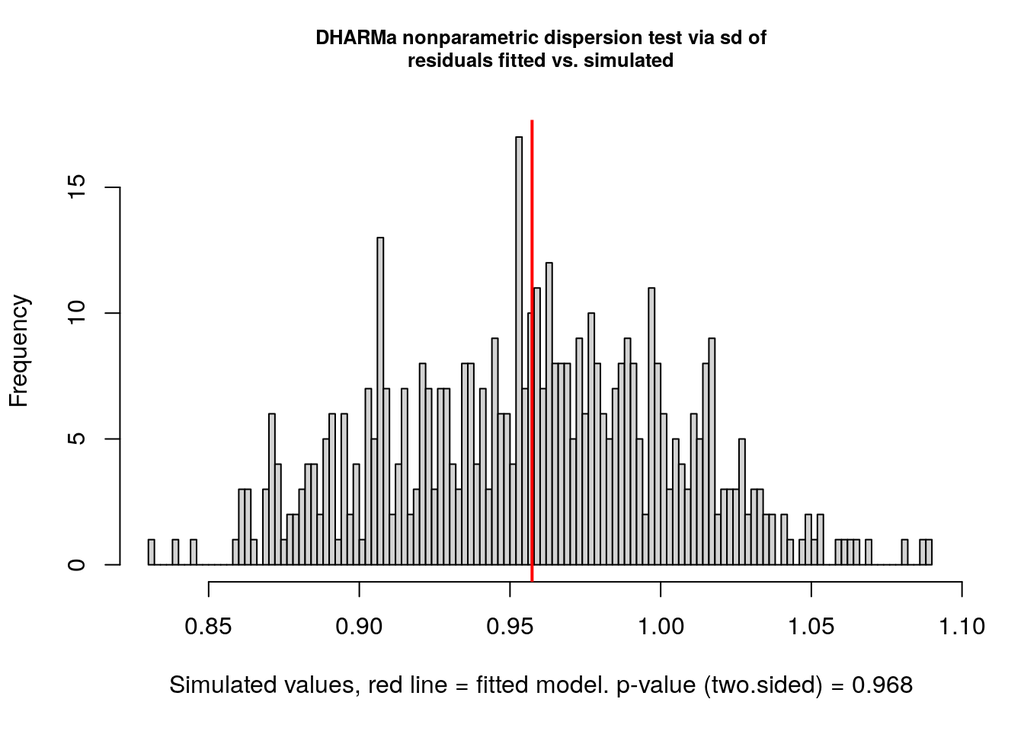

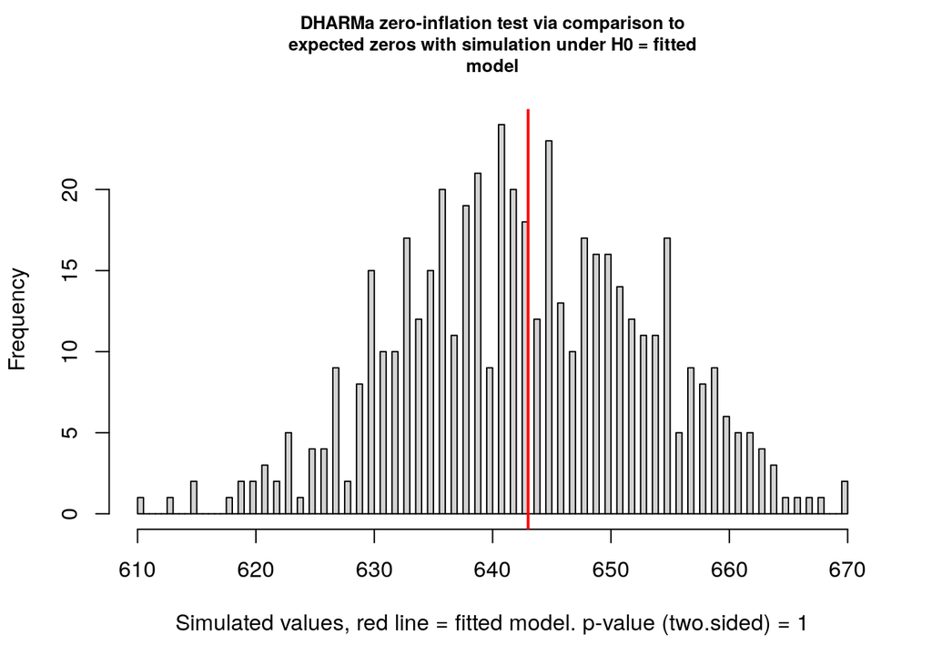

```
  Sensitivity (cloglog + offset log_dt): nssi
```

```
  Subset stats -> n=803, ids=459, fam=455, site=21, events=160, nonevents=643
```

```
[nssi | sens cloglog+offset] GLM refit; overdisp_K=1.007, max_VIF=1.09
```

```
  Sensitivity (bd_any_end): nssi
```

```
  Subset stats -> n=803, ids=459, fam=455, site=21, events=160, nonevents=643
```

```
[nssi | sens bd_any_end] GLM refit; overdisp_K=1.007, max_VIF=1.11
```

```
  Sensitivity (lag1 bd_any_start): nssi
```

```
[nssi | sens lag1(bd_any_start)] GLM refit; overdisp_K=1.006, max_VIF=1.08
```

### Final model for nssi

event ~ cluster + age_mid_between + sex + end_wave + bd_any_start <environment: 0x55a8311db030>

No random-effects variance (GLM refit).

```r
# Bind everything
wald_all_raw <- dplyr::bind_rows(purrr::compact(c(wald_primary, wald_sens_cloglog, wald_sens_end, wald_sens_lag1)))
cr2_all_raw  <- dplyr::bind_rows(purrr::compact(c(cr2_primary, cr2_sens_cloglog)))
pred_age_all <- dplyr::bind_rows(purrr::compact(preds_primary_age))
haz_wave_all <- dplyr::bind_rows(purrr::compact(hazards_wave_bd))
bd_contr_all <- dplyr::bind_rows(purrr::compact(bd_contrasts))
cal_all <- dplyr::bind_rows(purrr::compact(cal_primary))
auc_all <- dplyr::bind_rows(purrr::compact(auc_primary))
diag_all <- dplyr::bind_rows(purrr::compact(diag_primary))
perf_all <- dplyr::bind_rows(purrr::compact(perf_primary))
dharma_all <- dplyr::bind_rows(purrr::compact(dharma_tests_primary))

wald_all <- keep_terms(wald_all_raw)
cr2_all <- keep_terms(cr2_all_raw)

# Save
readr::write_csv(wald_all, file.path(OUT_DIR, "su_dth_wald.csv"))
readr::write_csv(cr2_all,  file.path(OUT_DIR, "su_dth_cr2.csv"))
readr::write_csv(wald_all_raw, file.path(OUT_DIR, "su_dth_wald_full.csv"))
readr::write_csv(cr2_all_raw, file.path(OUT_DIR, "su_dth_cr2_full.csv"))
readr::write_csv(pred_age_all, file.path(OUT_DIR, "su_dth_preds_by_age_by_bd.csv"))
readr::write_csv(haz_wave_all, file.path(OUT_DIR, "su_dth_hazard_by_wave_by_bd.csv"))
readr::write_csv(bd_contr_all, file.path(OUT_DIR, "su_dth_bd_contrasts_by_age.csv"))
readr::write_csv(cal_all, file.path(OUT_DIR, "su_dth_calibration.csv"))
readr::write_csv(auc_all, file.path(OUT_DIR, "su_dth_auc.csv"))
readr::write_csv(diag_all, file.path(OUT_DIR, "su_dth_diagnostics.csv"))
readr::write_csv(perf_all, file.path(OUT_DIR, "su_dth_performance.csv"))
readr::write_csv(dharma_all, file.path(OUT_DIR, "su_dth_dharma_tests.csv"))

# Summarize models kept and participant SD
re_summary <- purrr::imap_dfr(fits_qc_glmm, function(m, out) {
  if (inherits(m, "merMod")) {
    vc <- lme4::VarCorr(m)
    sd_part <- tryCatch(attr(vc[["participant_id"]], "stddev")[1], error = function(e) NA_real_)
    tibble(outcome = out, has_participant_RE = !is.na(sd_part), participant_SD = sd_part)
  } else {
    tibble(outcome = out, has_participant_RE = FALSE, participant_SD = NA_real_)
  }
})
knitr::kable(re_summary, digits = 6, caption = "QC GLMM fits: (1|participant_id) presence & SD")
```

QC GLMM fits: (1|participant_id) presence & SD

| outcome | has_participant_RE | participant_SD |
| --- | --- | --- |
| si_passive | TRUE | 0.000000 |
| si_active | TRUE | 0.000000 |
| sa | TRUE | 21.061578 |
| nssi | TRUE | 0.000000 |

```r
# Save models
purrr::iwalk(fits_primary, ~ saveRDS(.x, file.path(OUT_DIR, glue::glue("fit_primary_{.y}.rds"))))
purrr::iwalk(fits_sens_cloglog, ~ saveRDS(.x, file.path(OUT_DIR, glue::glue("fit_cloglog_{.y}.rds"))))
purrr::iwalk(fits_sens_end, ~ saveRDS(.x, file.path(OUT_DIR, glue::glue("fit_logit_bdend_{.y}.rds"))))
purrr::iwalk(fits_sens_lag1, ~ saveRDS(.x, file.path(OUT_DIR, glue::glue("fit_logit_bdlag1_{.y}.rds"))))
```

## 3) Marginal Effects & Visual QC

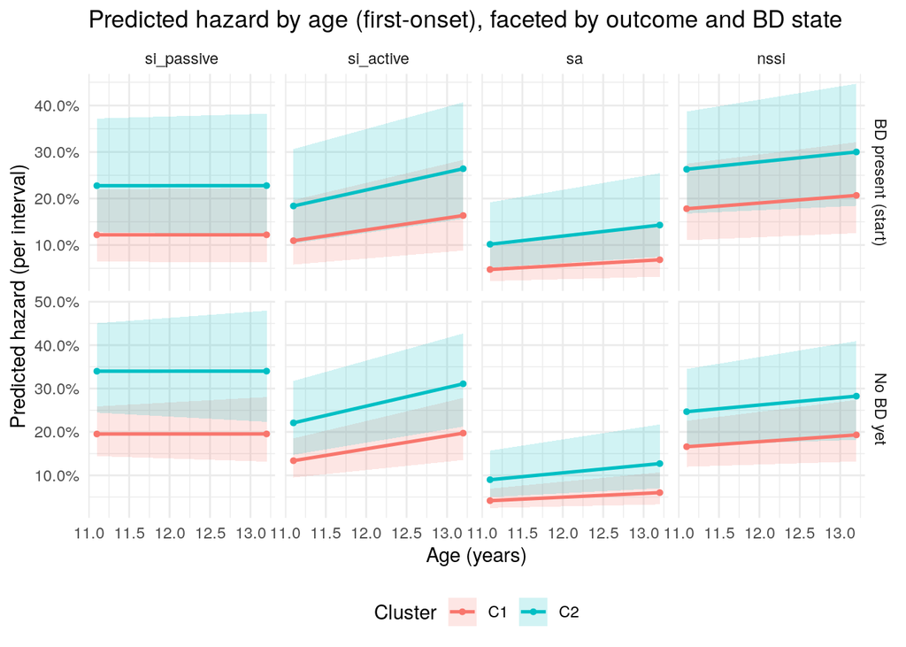

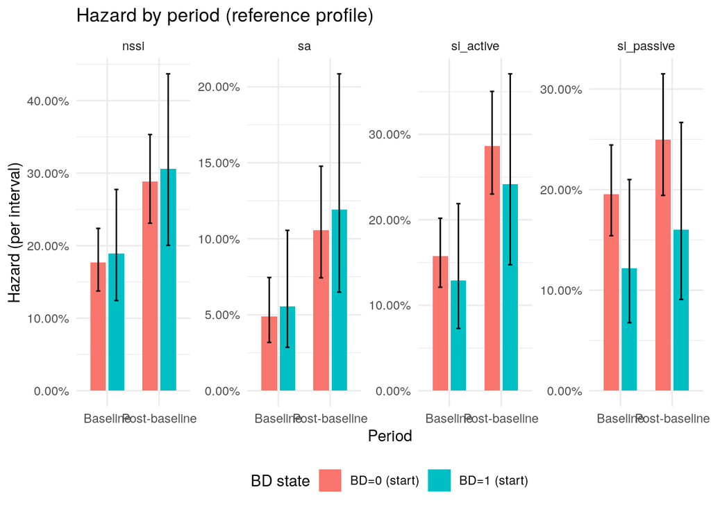